# Designing Evolution & Coevolution in a Video Game

### Ari Carter

## Backgound

- Peaceful trial for Polymorphic Games
  - Previous games used evolution to beat player
  - Space invaders
- Focused on open-ended game for younger audience

## Evolution

- Organisms want kids
  - Different pressures shape which can have kids
  - Organisms' traits assist, detract, or do nothing
    - Helpful traits promoted
    - Unhelpful traits squished
    - Useless stuff stays around
- Fitness function: a pressure that drives reproduction, trait emphasis

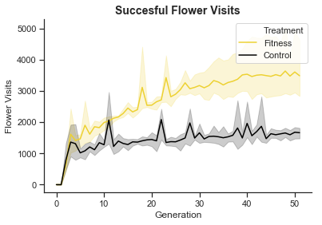

```python
FitnessExample()
```

## Coevolution Premise

- Pollinators and flowers
  - Usually mutually beneficial
  - Assist each other's reproduction
  - Broadly underlines ecosystem cause/effect
- Serve it up in a video game about cultivating honey
  - Players experience & employ principles
    - Artificial selection!
    - Ecosystem patterns

## Overview

- Genomes determine behavior & aesthetics
- Evolution occurs in rounds
- Niches occur over time
  - Collect 'em all

[figure not shown]

## Bee Operation

- Genome: nectar capacity, sight range, rate of release from hive, courage, patience, speed
- All leave hive when round begins
  - Collect nectar until capacity is reached
  - Return to hive
  - Repeat once rate of release lapsed
- While collecting nectar...
  - Contribute to/access hive memory
  - Find new flowers depending on courage, patience, sight
  - Distribute pollen
- Reproduce (asexually) at end of round

## Flower Operation

- Genome: Nectar capacity, nectar refill rate, pollen stickiness, pistil stickiness
- Hang out and look appetizing
  - Bees exchange nectar for chance of passing pollen
  - Can also recieve pollen (sexual reproduction)

## Fitness

- Bees playing roulette
  - More nectar, more chance to have kids
- Flowers play similar game
  - More pollen distributed, better chances
- Random mutation during reproduction

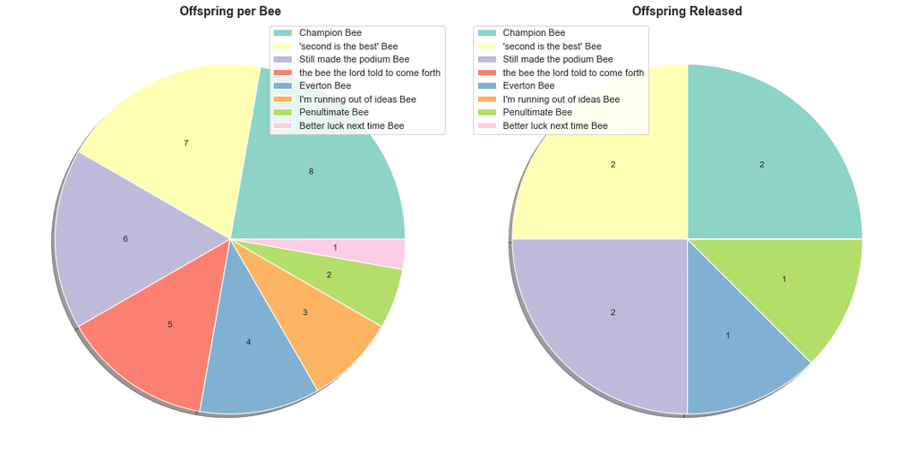

```python
RouletteExample()
```

## Demonstrating Evolution & Coevolution

- Toggle fitness
  - Do flowers evolve differently if bees are under pressure to evolve?
- Game too chaotic
  - Niches
  - Player
- Controls:
  - 1 hive with 200 bees/generation
  - 200 flowers
  - 50 rounds per replicate
  - Bee fitness function toggled every other replicate

## Evolution Results (Bees)

- Product of conditions
  - Exploration discouraged

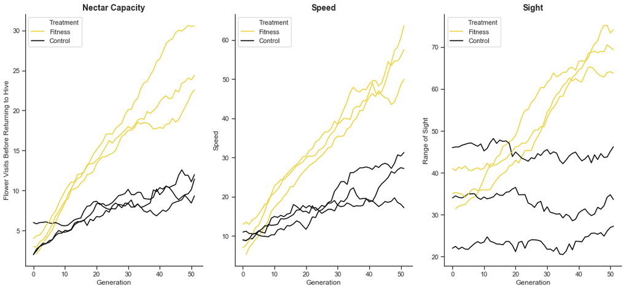

```python
BeeSelection()
```

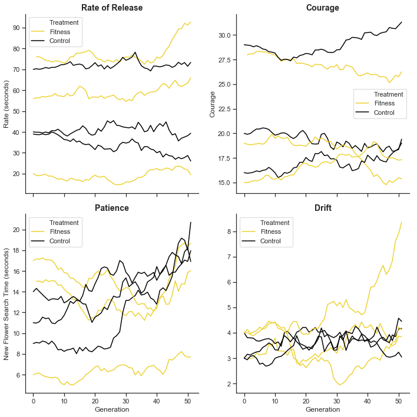

```python
BeeNoSelection()
```

## Coevolution Results (Flowers)

- Refill rate behaved strange
- Pollen stickiness

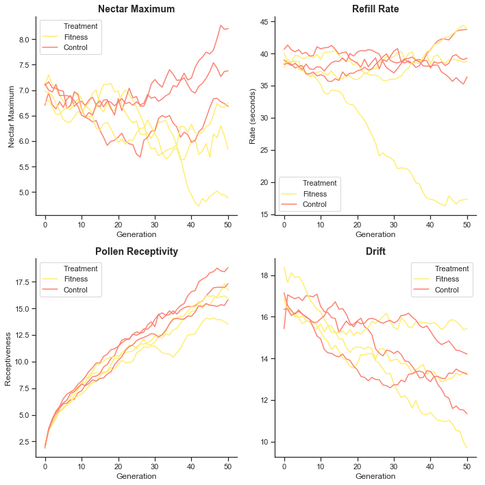

```python
FlowerNoSelection()
```

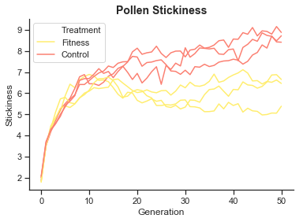

```python
PollenStickiness()
```

## Conclusions

- Coevolution evidence
- Aritificial selection
  - Educational tool
- Just fun